# Investigating Temperature Change on Land in relation to Climate Change

## Introduction

Over the years, both [natural and anthropogenic influences](https://www.epa.gov/climatechange-science/causes-climate-change#:~:text=Human%20and%20natural%20factors%20both,observed%20over%20the%20last%20century.) have contributed to major changes in the Earth's climate. The increase in [land surface temperatures](https://earthobservatory.nasa.gov/global-maps/MOD_NDVI_M/MOD_LSTD_M#:~:text=Land%20surface%20temperature%20is%20a,cools%20more%20quickly%20than%20air.), a major sign of [global warming](https://www.nrdc.org/stories/global-warming-101#causes), is among the most alarming occurrences associated with these changes. In addition to demonstrating the magnitude of climate change, land temperature change offers information about wider implications for ecosystems, [biodiversity](https://www.worldwildlife.org/pages/what-is-biodiversity#:~:text=Biodiversity%20is%20all%20the%20different,maintain%20balance%20and%20support%20life.), and human societies. These changes, which range from greater seasonal temperature variability to previously unheard-of peaks in recorded values, are a reflection of the growing effects of human activities including [industrialization](https://en.wikipedia.org/wiki/Industrialisation), [deforestation](https://education.nationalgeographic.org/resource/deforestation/), and [greenhouse gas emissions](https://www.ibm.com/think/topics/greenhouse-gas-emissions#:~:text=The%20release%20of%20certain%20gases,trap%20heat%20within%20our%20atmosphere.).

In Nigeria and around the world, the consequences of escalating temperatures are becoming ever more evident. The degradation of forests, the proliferation of urban landscapes, and the increasing dependence on [fossil fuels](https://en.wikipedia.org/wiki/Fossil_fuel) have collectively fostered a warming trend that jeopardizes the equilibrium of both natural ecosystems and human societies.

This study explores the trends in land temperature change over time, emphasizing how it relates to climate change and the impact of global climate events and policy. By examining decades' worth of temperature data, we hope to identify the patterns, fluctuations, and key milestones that characterize the current climate catastrophe and highlight how urgently meaningful action is needed to reduce its effects.

## Data Source

[FAOSTAT](https://www.fao.org/land-water/land/land-governance/land-resources-planning-toolbox/category/details/en/c/1029516/#:~:text=FAOSTAT%20is%20FAO%27s%20global%20statistical,the%20most%20recent%20year%20available.) is FAO’s global statistical database. It provides free access to food and agriculture data for over 245 countries and territories and covers all FAO regional groupings from 1961 to the most recent year available.

The FAOSTAT Temperature change on land domain disseminates statistics of mean surface temperature change by country, with annual updates. The current dissemination covers the period 1961–2023. Statistics are available for monthly, seasonal and annual mean temperature anomalies, i.e., temperature change with respect to a baseline climatology, corresponding to the period 1951–1980. The standard deviation of the temperature change of the baseline methodology is also available. Data are based on the publicly available GISTEMP data, the Global Surface Temperature Change data distributed by the National Aeronautics and Space Administration Goddard Institute for Space Studies (NASA-GISS). For more information, click [here](https://data.giss.nasa.gov/gistemp/)

## Data Visualizations

### Viewing the Dataset

|  | area_code | area_code_(m49) | area | months_code | months | year | unit | flag | standard_deviation | temperature_change |
| --- | --- | --- | --- | --- | --- | --- | --- | --- | --- | --- |
| 0 | 1 | '051 | Armenia | 7001 | January | 1992-01-01 | °c | E | 2.805 | -2.405 |
| 1 | 1 | '051 | Armenia | 7001 | January | 1993-01-01 | °c | E | 2.805 | -1.510 |
| 2 | 1 | '051 | Armenia | 7001 | January | 1994-01-01 | °c | E | 2.805 | 1.970 |
| 3 | 1 | '051 | Armenia | 7001 | January | 1995-01-01 | °c | E | 2.805 | 2.202 |
| 4 | 1 | '051 | Armenia | 7001 | January | 1996-01-01 | °c | E | 2.805 | 0.844 |
| ... | ... | ... | ... | ... | ... | ... | ... | ... | ... | ... |
| 285525 | 5873 | '198 | OECD | 7020 | Meteorological year | 2019-01-01 | °c | E | 0.259 | 1.291 |
| 285526 | 5873 | '198 | OECD | 7020 | Meteorological year | 2020-01-01 | °c | E | 0.259 | 1.431 |
| 285527 | 5873 | '198 | OECD | 7020 | Meteorological year | 2021-01-01 | °c | E | 0.259 | 1.589 |
| 285528 | 5873 | '198 | OECD | 7020 | Meteorological year | 2022-01-01 | °c | E | 0.259 | 1.237 |
| 285529 | 5873 | '198 | OECD | 7020 | Meteorological year | 2023-01-01 | °c | E | 0.259 | 1.706 |

285530 rows × 10 columns

### 1. How has the average temperature change evolved over the decades for Nigeria?

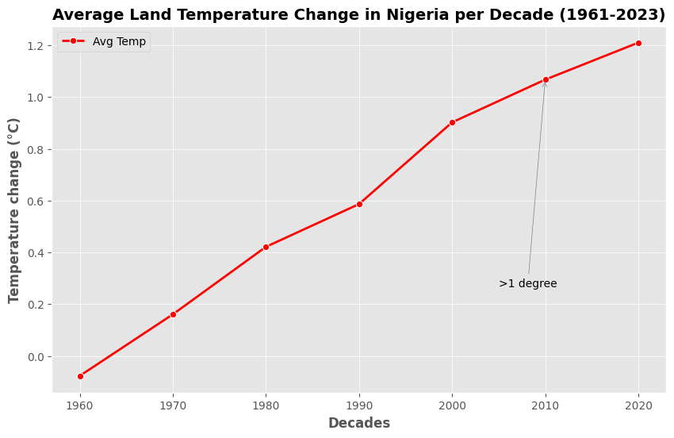

*There was an increasing trend in the temperature change for Nigeria over the decades (1960-2020). Also, although the temperature change surpassed 1°C in 2010, it never got to 1.5°C.*

*This increment in temperature over time indicates global warming or regional climate change, potentially linked to anthropogenic activities such as deforestation, urbanization, or greenhouse gas emissions. This may also explain the current [biodiversity loss](https://www.thecable.ng/biodiversity-in-nigeria-challenges-and-opportunities/) in the area (Nigeria). The WWF also recorded that Nigeria lost 1 million hectares of forest land between 2000 and 2015 due to logging, mining activities, infrastructure projects such as roads and dams, and land clearing for agriculture such as cocoa cultivation. Such activities can lead to both carbon sink and biodiversity loss.*

### 2. Are there discernible trends in the Global standard deviation of temperature changes over the years?

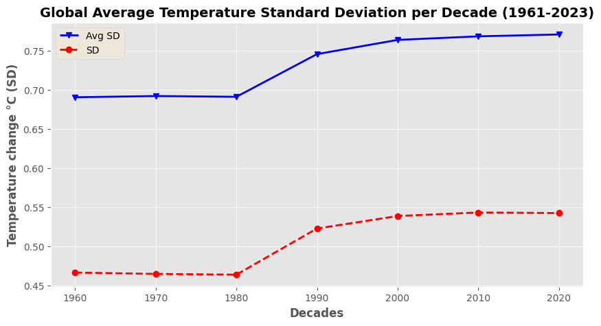

*The Standard Deviation (SD) of temperature change recorded for each year in each area was collected and the average SD per decade for countries in the `area` column was computed and plotted on the line pot above.*

*The increasing standard deviation indicates rising disparities in temperature changes globally and [post-1990](https://www.researchgate.net/publication/289678817_Evaluating_global_warming_A_post-1990s_perspective) trend coincides with accelerated global warming, industrialization, and greenhouse gas emissions, which are likely contributors to greater variability. Although the [1990s](https://www.researchgate.net/figure/The-1990s-was-the-warmest-decade-ever-recorded-instrumentally-The-last-100-years-were_fig3_253251122) recorded one of the warmest period, a [research](https://www.theguardian.com/environment/2010/jan/29/water-vapour-climate-change#:~:text=The%20research%2C%20led%20by%20one,human%20emissions%20of%20greenhouse%20gases.), headed by one of the world's leading climate scientists indicates that, rather than human greenhouse gas emissions, a rise in water vapor in the upper atmosphere was responsible for over one-third of the global warming observed in the 1990s.*

### 3. Are there recurring patterns in temperature changes across months within a year?

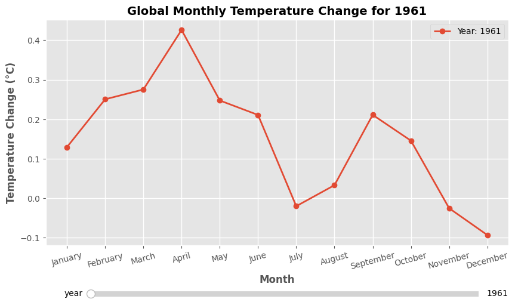

*For the first year (1961) of measurement, the highest land temperature change was recorded in April (Spring), and this change was not up to 0.5°C. The early-winter period (december) also recorded the lowest temperature change value, though it picked up the next year (1962) in January and significantly dropped again in February. The value of the temperature change began to decrease and stayed comparatively low and steady for subsequent years until 1966 and 1969 where the temperature change got back to nearly 0.6°C and 0.5°C respectively like the base line year.*

*In 1970, the first [World Earth Day](https://en.wikipedia.org/wiki/Earth_Day) was celebrated, the peak temperature change at the time was not up to 0.4°C, and the least temperature recorded in early-winter (December) was just a little below -0.1°C. Five years after that, the temperature change across the year (1975) was quite low. The highest value was recorded in January (around 0.25°C), with December recording a temperature change of nearly -0.4°C, this may be as a result of early changes in awareness and initial policy shifts. Investigating further, five years later, it can be seen that the temperature change has increased since 1975, with the peak temperature change value (close to 0.35°C) recorded in late-winter (February), and December having a value very close to but not equal to -0.1°C.*

*In 2015, the least temperature recorded was in mid-spring (April), while the peak temperature change (**1.60°C**) was seen in Early winter (December). This is the **highest** since 1988. Such reading may also be one of the contributing factor to the [Paris Climate Agreement](https://www.un.org/en/global-issues/climate-change#:~:text=At%20the%2021st%20Conference%20of,have%20ratified%20the%20Paris%20Agreement.) with an overarching goal to enhance sustainable development, reduce global warming, and increase resilience to the effects of climate change. Continuing to the next year (2016), the temperature dropped in mid-winter (January) and rose again in late-winter to about 1.85°C. Subsequent years (2017 & 2018) revealed that the peak temperature change remained relatively stable around 1.5°C during the spring period, then continued to rise from 2019, with 2020 and 2023 recording peak temperatures of **1.93°C** and **2.0°C** in late-winter and early-autumn respectively. These were the highest land temperature change recorded since 1961.*

### 4. How does the global temperature change from the first decade of the dataset compare to the last decade?

```
The difference in the temperature change of the first decade in comparison to the last decade is 1.40 °C
```

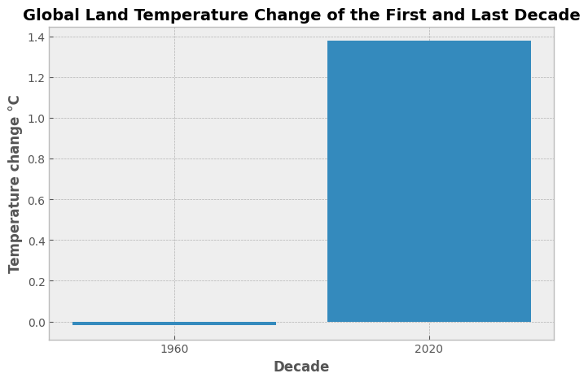

*These difference of **1.40°C** between the first and last decade suggests a rapidly significant warming trend, possibly due to [climate change](https://www.un.org/en/climatechange/what-is-climate-change) or other environmental factors.*

*The Intergovernmental Panel on Climate Change (IPCC) emphasizes that a [1.5°C global increase](https://www.ipcc.ch/sr15/) over pre-industrial levels is linked to serious threats to ecosystems and human systems, making a 1.40°C increase extremely significant. A sixty-year increase of 1.40°C signifies a substantial and concerning long-term warming trend that is greater than historical natural variability.*

### 5. Are there any years with extreme temperature changes compared to the long-term average?

Using the [2-SD rule or 95th percentile rule](https://calculator.academy/2-standard-deviation-rule-calculator/), any value that goes above or below the lower and upper threshold respectively (for the 2-SD), or the 95th and 5th percentile will be considered extreme or unusual.

```
No year recorded an unusual or extreme temperature change value
```

### 6. What is the rate of temperature change per year for each area?

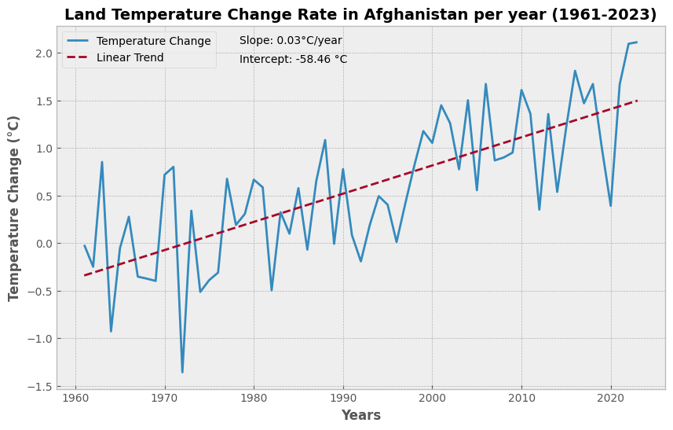

## Limitation(s)

- The country/region that makes up the global analysis, do not have every single area of the world in it.

## Conclusion

According to the analysis, there has been a notable and alarming warming trend in Nigeria and around the world over the past 60 years, with an average increase in land temperature change of 1.40°C. This trend is consistent with the effects of regional and global climate change, which are influenced by human activities like urbanization, deforestation, and greenhouse gas emissions.

The variability in temperature change, as shown by rising standard deviation, has also increased, especially after 1990, reflecting accelerated industrialization and policy delays such as those during the Kyoto Protocol negotiations. Although global initiatives like the 1988 establishment of the IPCC and the 2015 Paris Climate Agreement have attempted to lessen these impacts, the data emphasizes the enduring difficulties and the pressing need for more robust climate action. Rising global temperature differences and their dire ecological effects highlight the urgent need for concerted, long-term measures to mitigate climate change and improve environmental resilience.